# STAT 430/830: Final Project Sketch Solutions

The following is an account of my experimental journey toward the optimum. It does not represent formal solutions for the report, but merely an illustration of the experiments and choices I would have made if I was doing the project. Hopefully this serves as a useful benchmark against which you can compare your own experiments and choices. Note that here I am interacting with the STAT 430 simulated surface (i.e., I ignore the `Top.Row` factor). And so that everything is fair, I collected all of my data using the simulator, just like you did.

## PHASE I: Factor Screening

At this stage I ran a full $2^3$ factorial design to determine which of the three factors `Tile.Size`, `Prev.Size` and `Prev.Length` significantly influence the response variable, `Browse.Time`. This design is visualized below.

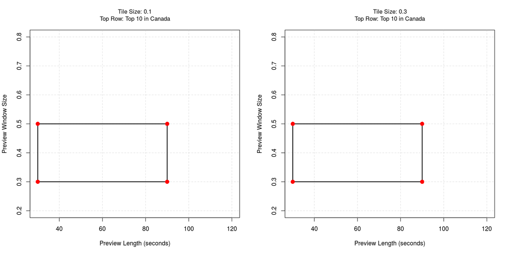

I’ll analyze the resulting data ($n=250$ browse time observations in each of the $2^3=8$ experimental conditions) using a linear regression model containing main effects, two-factor interactions, and the three-factor interaction.

```r
## Read in the data outputted by the simulator
ph1 <- read.csv(file = "factorial1.csv", header = TRUE)

## Convert the levels from natural to coded units
ph1.coded <- data.frame(Tile.Size = convert.N.to.C(xN = ph1$Tile.Size, H = 0.3, L = 0.1),
                        Prev.Size = convert.N.to.C(xN = ph1$Prev.Size, H = 0.5, L = 0.3),
                        Prev.Length = convert.N.to.C(xN = ph1$Prev.Length, H = 90, L = 30),
                        Browse.Time = ph1$Browse.Time)

## Fit the linear regression model
m1 <- lm(Browse.Time ~ Tile.Size * Prev.Size * Prev.Length, data = ph1.coded)
summary(m1)
```

```
##
## Call:
## lm(formula = Browse.Time ~ Tile.Size * Prev.Size * Prev.Length,
##     data = ph1.coded)
##
## Residuals:
##      Min       1Q   Median       3Q      Max
## -10.0927  -2.0162   0.0256   1.9865   9.7483
##
## Coefficients:
##                                 Estimate Std. Error t value Pr(>|t|)
## (Intercept)                     19.11822    0.06718 284.576   <2e-16 ***
## Tile.Size                        0.10608    0.06718   1.579    0.115
## Prev.Size                       -0.83472    0.06718 -12.425   <2e-16 ***
## Prev.Length                     -0.82057    0.06718 -12.214   <2e-16 ***
## Tile.Size:Prev.Size              0.03105    0.06718   0.462    0.644
## Tile.Size:Prev.Length            0.04771    0.06718   0.710    0.478
## Prev.Size:Prev.Length           -0.72227    0.06718 -10.751   <2e-16 ***
## Tile.Size:Prev.Size:Prev.Length -0.10238    0.06718  -1.524    0.128
## ---
## Signif. codes:  0 '***' 0.001 '**' 0.01 '*' 0.05 '.' 0.1 ' ' 1
##
## Residual standard error: 3.004 on 1992 degrees of freedom
## Multiple R-squared:  0.1757, Adjusted R-squared:  0.1728
## F-statistic: 60.67 on 7 and 1992 DF,  p-value: < 2.2e-16
```

The output above indicates that the factors `Prev.Size` and `Prev.Length` are active and `Tile.Size` is not. I will therefore, in subsequent experiments, focus solely on `Prev.Size` and `Prev.Length` and ignore `Tile.Size` entirely.

$\;$

## PHASE II: Method of Steepest Descent

Having identified `Prev.Size` and `Prev.Length` as the active factors I next fit a first order surface with just these two factors in order to determine – and subsequently embark on – the path of steepest descent. Below I fit and visualize this model.

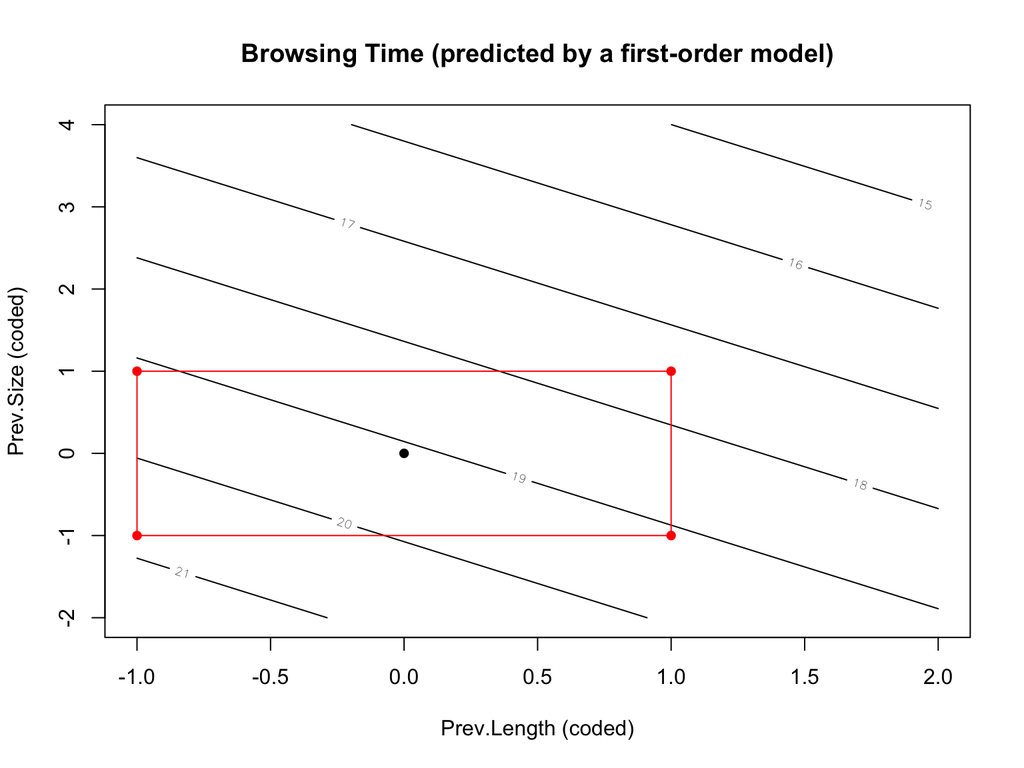

```r
## Fit the model
fo.m <- lm(Browse.Time ~ Prev.Size + Prev.Length, data = ph1.coded)

## Construct a 2D contour plot
beta0 <- coef(fo.m)[1]
beta1 <- coef(fo.m)[2]
beta2 <- coef(fo.m)[3]
grd <- mesh(x = seq(30,120, length.out = 100), y = seq(0.2,0.8, length.out = 100))
x1.pred <- convert.N.to.C(xN = grd$x, H = 90, L = 30)
x2.pred <- convert.N.to.C(xN = grd$y, H = 0.5, L = 0.3)
pred.fo <- beta0 + beta1*x1.pred + beta2*x2.pred
contour(x = convert.N.to.C(xN = seq(30,120, length.out = 100), H = 90, L = 30),
        y = convert.N.to.C(xN = seq(0.2,0.8, length.out = 100), H = 0.5, L = 0.3),
        z = pred.fo, xlab = "Prev.Length (coded)", ylab = "Prev.Size (coded)",
        main = "Browsing Time (predicted by a first-order model)")
points(x = c(-1,-1,1,1), y = c(-1,1,-1,1), col = "red", pch = 16)
points(x = 0, y = 0, pch = 16)
segments(x0 = -1, y0 = -1, x1 = -1, y1 = 1, col = "red")
segments(x0 = -1, y0 = -1, x1 = 1, y1 = -1, col = "red")
segments(x0 = 1, y0 = -1, x1 = 1, y1 = 1, col = "red")
segments(x0 = -1, y0 = 1, x1 = 1, y1 = 1, col = "red")
```

The red dots and rectangle above indicate experimental conditions for which I already have data, and the black dot indicates a fifth, a center point condition, that I will run in order to test for quadratic curvature and determine whether I am in the vicinity of the optimum to begin with.

```r
## Read in the center point data, transform it to coded units and add it to the data we've already collected
cp <- read.csv(file = "cp.csv", header = TRUE)
cp.coded <- data.frame(Tile.Size = convert.N.to.C(xN = cp$Tile.Size, H = 0.3, L = 0.1),
                       Prev.Size = convert.N.to.C(xN = cp$Prev.Size, H = 0.5, L = 0.3),
                       Prev.Length = convert.N.to.C(xN = cp$Prev.Length, H = 90, L = 30),
                       Browse.Time = cp$Browse.Time)
fac.cp1.coded <- rbind(ph1.coded, cp.coded)

## Fit a model with a pure quadratic term
fac.cp1.coded$PQ <- (fac.cp1.coded$Prev.Size^2 + fac.cp1.coded$Prev.Length^2)/2
pq.m <- lm(Browse.Time ~ Prev.Size * Prev.Length + PQ, data = fac.cp1.coded)
summary(pq.m)
```

```
##
## Call:
## lm(formula = Browse.Time ~ Prev.Size * Prev.Length + PQ, data = fac.cp1.coded)
##
## Residuals:
##      Min       1Q   Median       3Q      Max
## -10.2845  -1.9920  -0.0282   1.9546   9.9401
##
## Coefficients:
##                       Estimate Std. Error t value Pr(>|t|)
## (Intercept)           19.84411    0.19010  104.39  < 2e-16 ***
## Prev.Size             -0.83472    0.06721  -12.42  < 2e-16 ***
## Prev.Length           -0.82057    0.06721  -12.21  < 2e-16 ***
## PQ                    -0.72589    0.20163   -3.60 0.000325 ***
## Prev.Size:Prev.Length -0.72227    0.06721  -10.75  < 2e-16 ***
## ---
## Signif. codes:  0 '***' 0.001 '**' 0.01 '*' 0.05 '.' 0.1 ' ' 1
##
## Residual standard error: 3.006 on 2245 degrees of freedom
## Multiple R-squared:  0.1613, Adjusted R-squared:  0.1598
## F-statistic: 107.9 on 4 and 2245 DF,  p-value: < 2.2e-16
```

The output above indicates that the p-value associated with the pure quadratic term is roughly 0.0003, suggesting statistically significant quadratic curvature at the usual 5% level. However, a p-value can be made arbitrarily small by taking an arbitrarily large sample size. The sample sizes here are quite large; 500 at each corner point and 250 at the center point. As such, I should consider whether the difference between the observed response at the corner points is *practically* different than at the center point. The coefficient estimate for the pure quadratic term is -0.72589, indicating that the difference between the average browsing time at the corner points versus the center point is only 0.72589 (or 44 seconds). This difference is not practically substantial and so I conclude that it is unlikely that I am in the vicinity of the optimum, and so I will continue forward with a path of steepest descent analysis in search of the region of the optimum.

Of course, this conclusion could be incorrect – if the steepest descent analysis indicates that I cannot improve upon my current position, I will return here and augment the points I already have to perform a full central composite design.

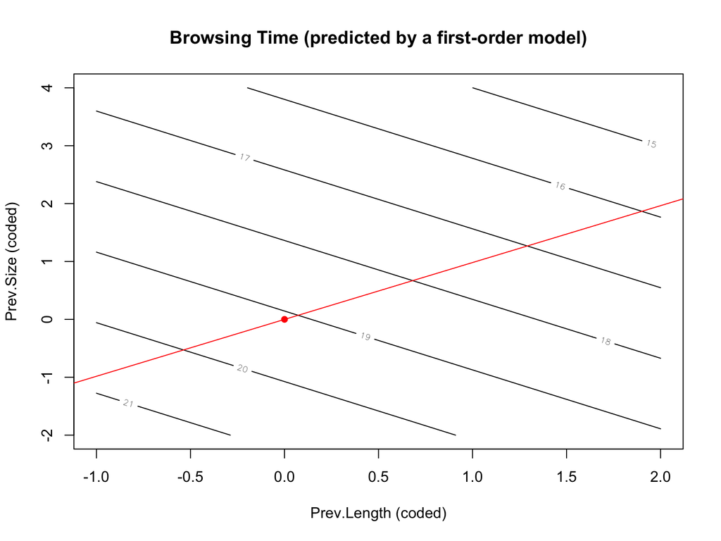

```r
contour(x = convert.N.to.C(xN = seq(30,120, length.out = 100), H = 90, L = 30),
        y = convert.N.to.C(xN = seq(0.2,0.8, length.out = 100), H = 0.5, L = 0.3),
        z = pred.fo, xlab = "Prev.Length (coded)", ylab = "Prev.Size (coded)",
        main = "Browsing Time (predicted by a first-order model)")
abline(a = 0, b = beta2/beta1, col = "red")
points(x = 0, y = 0, col = "red", pch = 16)
```

The path of steepest descent is shown above. I will perform experimental conditions along this path in increments of 10 seconds in `Prev.Length`, starting from the center point (60s, that I have already observed): 70s, 80s, 90s, 100s, 110s, 120s. The corresponding `Prev.Size` is determined by the gradient pictured above.

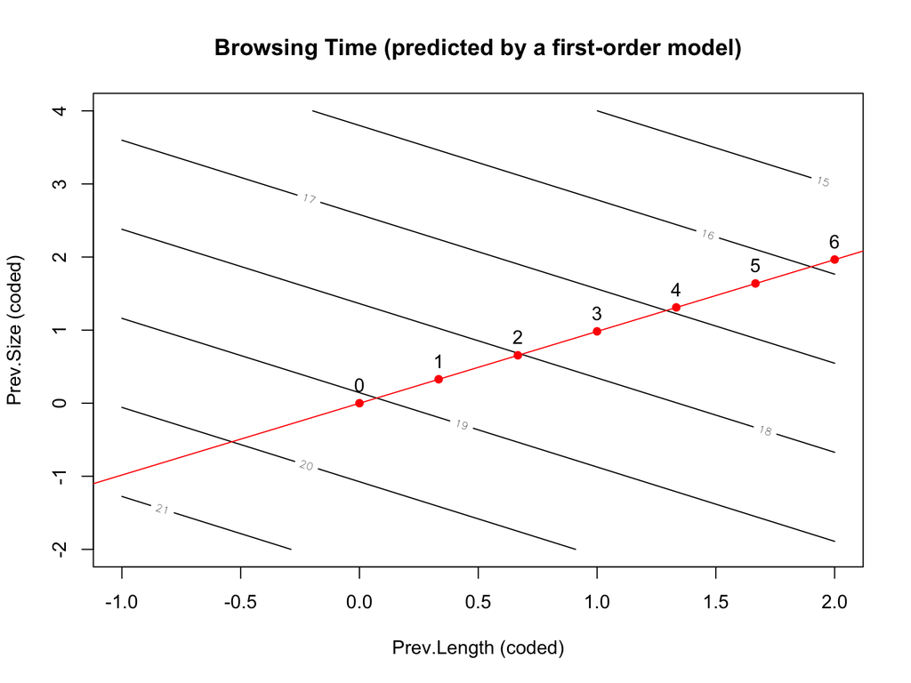

```r
# The gradient vector
g <- matrix(c(beta1, beta2), nrow = 1)

# We will take steps of size 10 seconds in preview length. In coded units this is
PL.step <- convert.N.to.C(xN = 60 + 10, H = 90, L = 30)
lamda <- PL.step/abs(beta1)

contour(x = convert.N.to.C(xN = seq(30,120, length.out = 100), H = 90, L = 30),
        y = convert.N.to.C(xN = seq(0.2,0.8, length.out = 100), H = 0.5, L = 0.3),
        z = pred.fo, xlab = "Prev.Length (coded)", ylab = "Prev.Size (coded)",
        main = "Browsing Time (predicted by a first-order model)")
abline(a = 0, b = beta2/beta1, col = "red")
points(x = 0, y = 0, col = "red", pch = 16)

## Step 0: The center point we've already observed
x.old <- matrix(0, nrow=1, ncol=2)
text(x = 0, y = 0+0.25, labels = "0")
step0 <- data.frame(Prev.Length = convert.C.to.N(xC = 0, H = 90, L = 30),
                 Prev.Size = convert.C.to.N(xC = 0, H = 0.5, L = 0.3))

## Step 1:
x.new <- x.old - lamda*g
step1 <- data.frame(Prev.Length = convert.C.to.N(xC = x.new[1,1], H = 90, L = 30),
                    Prev.Size = convert.C.to.N(xC = x.new[1,2], H = 0.5, L = 0.3))
points(x = x.new[1,1], y = x.new[1,2], col = "red", pch = 16)
text(x = x.new[1,1], y = x.new[1,2]+0.25, labels = "1")

## Step 2:
x.old <- x.new
x.new <- x.old - lamda*g
step2 <- data.frame(Prev.Length = convert.C.to.N(xC = x.new[1,1], H = 90, L = 30),
                    Prev.Size = convert.C.to.N(xC = x.new[1,2], H = 0.5, L = 0.3))
points(x = x.new[1,1], y = x.new[1,2], col = "red", pch = 16)
text(x = x.new[1,1], y = x.new[1,2]+0.25, labels = "2")

## Step 3:
x.old <- x.new
x.new <- x.old - lamda*g
step3 <- data.frame(Prev.Length = convert.C.to.N(xC = x.new[1,1], H = 90, L = 30),
                    Prev.Size = convert.C.to.N(xC = x.new[1,2], H = 0.5, L = 0.3))
points(x = x.new[1,1], y = x.new[1,2], col = "red", pch = 16)
text(x = x.new[1,1], y = x.new[1,2]+0.25, labels = "3")

## Step 4:
x.old <- x.new
x.new <- x.old - lamda*g
step4 <- data.frame(Prev.Length = convert.C.to.N(xC = x.new[1,1], H = 90, L = 30),
                    Prev.Size = convert.C.to.N(xC = x.new[1,2], H = 0.5, L = 0.3))
points(x = x.new[1,1], y = x.new[1,2], col = "red", pch = 16)
text(x = x.new[1,1], y = x.new[1,2]+0.25, labels = "4")

## Step 5:
x.old <- x.new
x.new <- x.old - lamda*g
step5 <- data.frame(Prev.Length = convert.C.to.N(xC = x.new[1,1], H = 90, L = 30),
                    Prev.Size = convert.C.to.N(xC = x.new[1,2], H = 0.5, L = 0.3))
points(x = x.new[1,1], y = x.new[1,2], col = "red", pch = 16)
text(x = x.new[1,1], y = x.new[1,2]+0.25, labels = "5")

## Step 6:
x.old <- x.new
x.new <- x.old - lamda*g
step6 <- data.frame(Prev.Length = convert.C.to.N(xC = x.new[1,1], H = 90, L = 30),
                    Prev.Size = convert.C.to.N(xC = x.new[1,2], H = 0.5, L = 0.3))
points(x = x.new[1,1], y = x.new[1,2], col = "red", pch = 16)
text(x = x.new[1,1], y = x.new[1,2]+0.25, labels = "6")
```

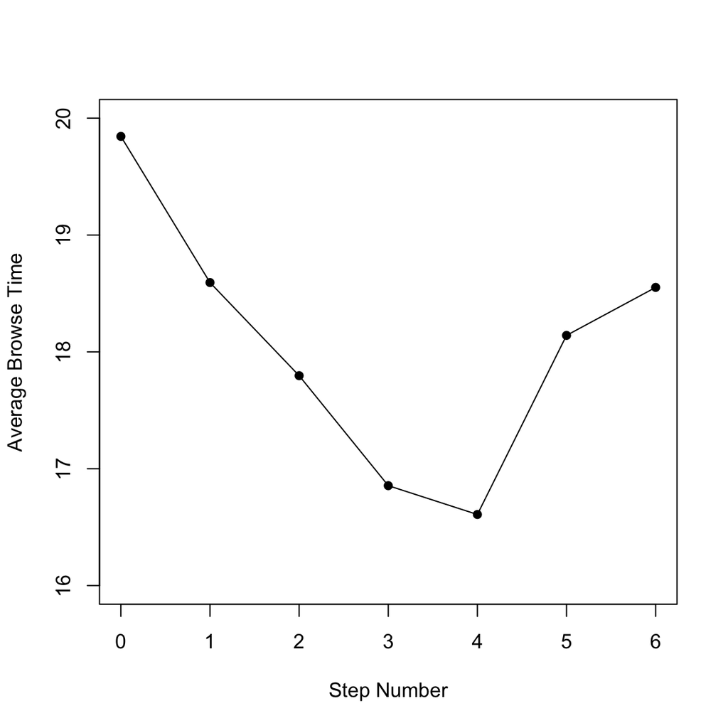

```r
## Read in the path of steepest descent data
posd <- read.csv(file = "posd.csv", header = TRUE)

## Add the center point data to this and visualize the average response
## along the path
posd <- rbind(cp, posd)
posd.means <- aggregate(x = posd$Browse.Time, by = list(posd$Prev.Length), FUN = mean)
plot(x = 0:6, y = posd.means$x, xlab = "Step Number", ylab = "Average Browse Time",
     type = "l", col = "black", ylim = c(16,20))
points(x = 0:6, y = posd.means$x, pch = 16, col = "black")
```

The plot above indicates that the lowest average `Browse.Time` observed along the path was at Step 4, corresponding to `Prev.Length = 100`. To further investigate this space I will add two more points along the path corresponding to `Prev.Length = 95` and `Prev.Length = 105` to determine whether average `Browse.Time` can be further improved.

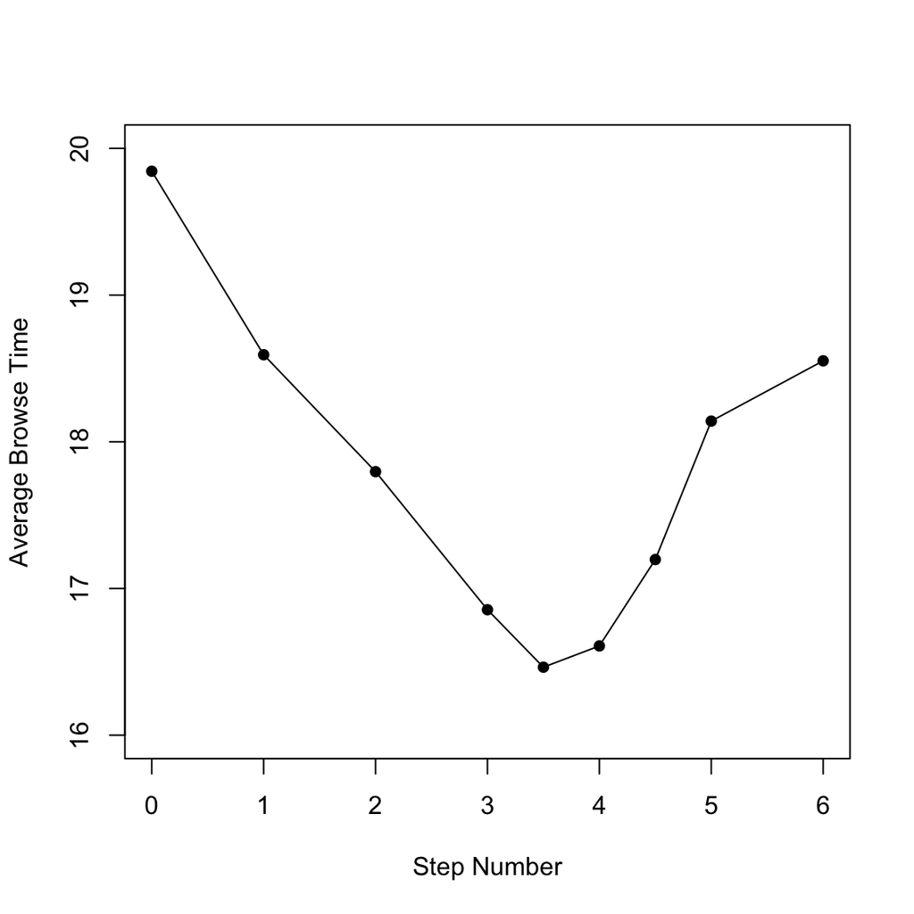

```r
## Read in the data from these two additional conditions
posd2 <- read.csv(file = "posdextra.csv", header = TRUE)
posd <- rbind(posd, posd2)
posd.means <- aggregate(x = posd$Browse.Time, by = list(posd$Prev.Length), FUN = mean)
plot(x = c(0,1,2,3,3.5,4,4.5,5,6), y = posd.means$x, xlab = "Step Number", ylab = "Average Browse Time",
     type = "l", col = "black", ylim = c(16,20))
points(x = c(0,1,2,3,3.5,4,4.5,5,6), y = posd.means$x, pch = 16, col = "black")
```

The plot above indicates that I have indeed improved average `Browse.Time` at Step 3.5, corresponding to `Prev.Length = 95`. Since I cannot change `Prev.Length` in increments less than 5 seconds, I cannot investigate `Prev.Length` in any more granularity. As such, I’ll stop here along the path and perform another test of quadratic curvature to determine whether I am now in the vicinity of the optimum.

The path of steepest descent conditions, in natural units, is visualized below.

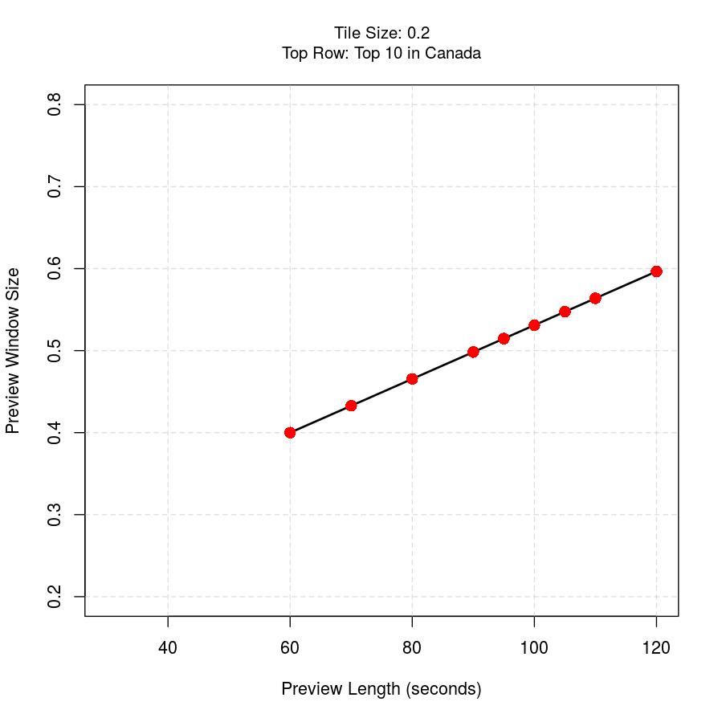

```r
## Read in the data from these factorial conditions
corners <- read.csv(file = "factorial2.csv", header = TRUE)

## Add in the center point of this design (the data from Step 3.5 above)
cp2 <- posd[posd$Prev.Length == 95,]
fac.cp2 <- rbind(corners, cp2)
fac.cp2.coded <- data.frame(Prev.Length = convert.N.to.C(xN = fac.cp2$Prev.Length, H = 110, L = 80),
                            Prev.Size = convert.N.to.C(xN = fac.cp2$Prev.Size, H = 0.6146889, L = 0.4146889),
                            Browse.Time = fac.cp2$Browse.Time)
fac.cp2.coded$PQ <- (fac.cp2.coded$Prev.Length^2 + fac.cp2.coded$Prev.Size^2)/2
pq.m2 <- lm(Browse.Time ~ Prev.Size * Prev.Length + PQ, data = fac.cp2.coded)
summary(pq.m2)
```

```
##
## Call:
## lm(formula = Browse.Time ~ Prev.Size * Prev.Length + PQ, data = fac.cp2.coded)
##
## Residuals:
##      Min       1Q   Median       3Q      Max
## -10.6090  -2.0146   0.1342   1.9952   7.9436
##
## Coefficients:
##                       Estimate Std. Error t value Pr(>|t|)
## (Intercept)           16.46322    0.18615  88.441  < 2e-16 ***
## Prev.Size             -1.21728    0.09307 -13.079  < 2e-16 ***
## Prev.Length            0.77250    0.09307   8.300 2.68e-16 ***
## PQ                     1.39056    0.20812   6.681 3.56e-11 ***
## Prev.Size:Prev.Length  0.31148    0.09307   3.347 0.000843 ***
## ---
## Signif. codes:  0 '***' 0.001 '**' 0.01 '*' 0.05 '.' 0.1 ' ' 1
##
## Residual standard error: 2.943 on 1245 degrees of freedom
## Multiple R-squared:  0.192,  Adjusted R-squared:  0.1894
## F-statistic: 73.94 on 4 and 1245 DF,  p-value: < 2.2e-16
```

The summary above indicates that the p-value associated with the pure quadratic term is extremely small – much much smaller than the last time I did a test for quadratic curvature. This suggests that I am indeed in the vicinity of the optimum and that fitting a full second-order model to identify the optimum precisely, is warranted.

$\;$

## PHASE III: Response Optimization

To fit a full second-order model and determine the location of the optimum precisely, I need to conduct a central composite experiment. At this point I have data from four factorial conditions and a center point condition. All I need now is data from four axial conditions. Because I’m close to the boundary of the region of operability (with respect to `Prev.Length`), and because `Prev.Length` can only be experimented with in increments of 5 seconds, I need to be careful with the values I choose. To ensure dispersion around the outside of the current factorial “box” while respecting these constraints I’ll choose the extremes of `Prev.Length` to be 70 and 120. For `Prev.Size` I choose the extremes to be $\sqrt2$ coded units from the center point. In natural units this corresponds to 0.3732675 and 0.6561103.

The full CCD is visualized below

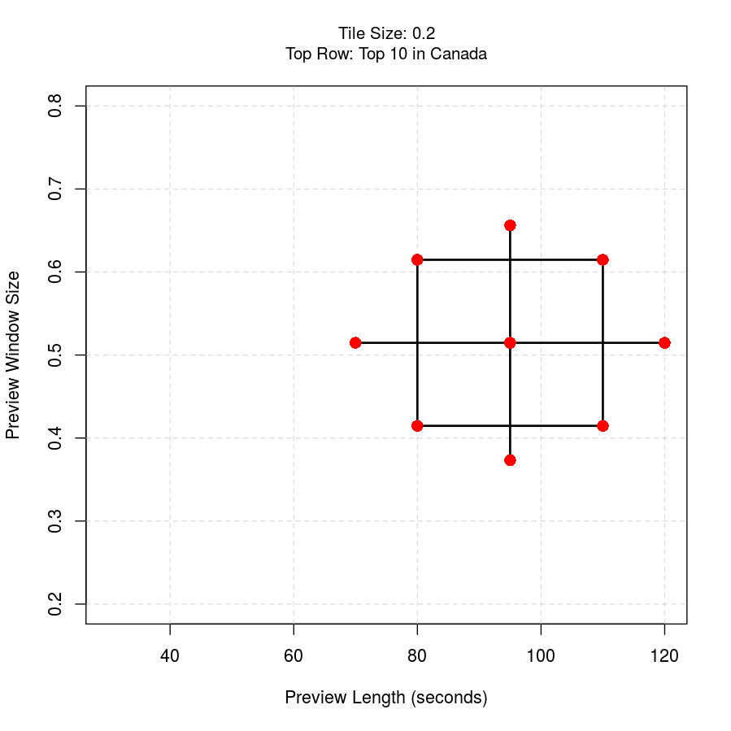

```r
## Read in the axial data and consolidate all CCD data into one dataframe
axial <- read.csv(file = "axial.csv", header = TRUE)
ccd <- rbind(fac.cp2, axial)
ccd.coded <- data.frame(Prev.Length = convert.N.to.C(xN = ccd$Prev.Length, H = 110, L = 80),
                        Prev.Size = convert.N.to.C(xN = ccd$Prev.Size, H = 0.6146889, L = 0.4146889),
                        Browse.Time = ccd$Browse.Time)

## Fit a second-order model
so.m <- lm(Browse.Time ~ Prev.Length*Prev.Size + I(Prev.Length^2) + I(Prev.Size^2), data = ccd.coded)
summary(so.m)
```

```
##
## Call:
## lm(formula = Browse.Time ~ Prev.Length * Prev.Size + I(Prev.Length^2) +
##     I(Prev.Size^2), data = ccd.coded)
##
## Residuals:
##      Min       1Q   Median       3Q      Max
## -10.8522  -2.0437   0.0427   2.0370  10.2127
##
## Coefficients:
##                       Estimate Std. Error t value Pr(>|t|)
## (Intercept)           16.52434    0.18647  88.616  < 2e-16 ***
## Prev.Length            0.52557    0.06165   8.525  < 2e-16 ***
## Prev.Size             -1.17233    0.06738 -17.399  < 2e-16 ***
## I(Prev.Length^2)       0.71869    0.08393   8.563  < 2e-16 ***
## I(Prev.Size^2)         0.50160    0.11568   4.336 1.51e-05 ***
## Prev.Length:Prev.Size  0.31148    0.09529   3.269   0.0011 **
## ---
## Signif. codes:  0 '***' 0.001 '**' 0.01 '*' 0.05 '.' 0.1 ' ' 1
##
## Residual standard error: 3.013 on 2244 degrees of freedom
## Multiple R-squared:  0.171,  Adjusted R-squared:  0.1691
## F-statistic: 92.56 on 5 and 2244 DF,  p-value: < 2.2e-16
```

Above I have fit the full second order model, containing main effects, the two-factor interaction, and the two quadratic effects. The results from the this model indicate that both quadratic terms are statistically significant, further substantiating that I am indeed in the vicinity of the optimum. Next I’ll visualize the fitted second-order surface and locate its stationary point.

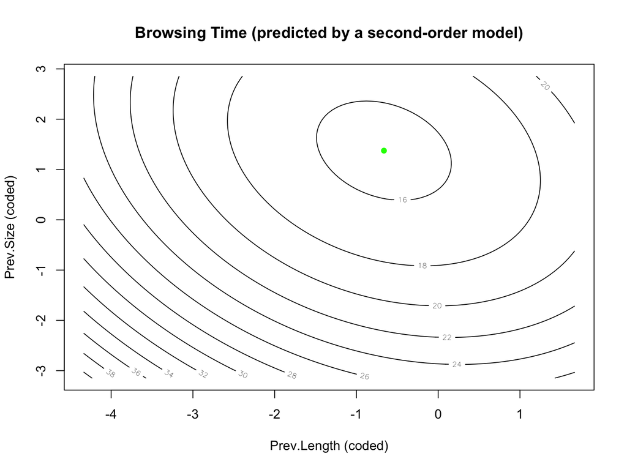

```r
## Visualize the fitted surface
grd <- mesh(x = seq(30,120, length.out = 100), y = seq(0.2,0.8, length.out = 100))
x1.pred <- convert.N.to.C(xN = grd$x, H = 110, L = 80)
x2.pred <- convert.N.to.C(xN = grd$y, H = 0.6146889, L = 0.4146889)
beta <- as.numeric(coef(so.m))
beta0 <- beta[1]
beta1 <- beta[2]
beta2 <- beta[3]
beta12 <- beta[6]
beta11 <- beta[4]
beta22 <- beta[5]
pred.so <- beta0 + beta1*x1.pred + beta2*x2.pred + beta12*x1.pred*x2.pred + beta11*x1.pred*x1.pred + beta22*x2.pred*x2.pred

## Visualize fitted response surface
contour(x = convert.N.to.C(xN = seq(30,120, length.out = 100), H = 110, L = 80),
        y = convert.N.to.C(xN = seq(0.2,0.8, length.out = 100), H = 0.6146889, L = 0.4146889),
        z = pred.so, xlab = "Prev.Length (coded)", ylab = "Prev.Size (coded)",
        main = "Browsing Time (predicted by a second-order model)")

## Find and plot the stationary point
b <- matrix(data = c(beta1, beta2), ncol = 1)
B <- matrix(data = c(beta11, beta12/2, beta12/2, beta22), nrow = 2, ncol = 2)
x.s <- -0.5*solve(B) %*% b
points(x = x.s[1], y = x.s[2], pch = 16, col = "green")
```

```r
x.s
```

```
##            [,1]
## [1,] -0.6635243
## [2,]  1.3746085
```

The location of the stationary point is identified in green above. In coded units this corresponds to (-0.6635243,1.3746085). The optimal predicted `Browse.Time` and its position in natural units is calculated below.

```r
beta[1] + 0.5 * t(x.s) %*% b
```

```
##          [,1]
## [1,] 15.54423
```

```r
c(convert.C.to.N(xC = x.s[1,1], H = 110, L = 80), convert.C.to.N(xC = x.s[2,1], H = 0.6146889, L = 0.4146889))
```

```
## [1] 85.0471356  0.6521497
```

Thus, my experimentation has lead to the final conclusion that `Prev.Length = 85.0471356` and `Prev.Size = 0.6521497` is optimal, and the predicted `Browse.Time` at this position is 15.54423. The true optimum is `Prev.Length = 84.5455` and `Prev.Size = 0.6667`, at which `Browse.Time = 15`. Comparing my results to this, you can see that using the basic methodology from class, and a total of 24 conditions, II was able to get quite close to the truth.

Note that in terms of scoring, I would have gotten full accuracy points, but I ran a total of 24 conditions so I would have only received 1 of 2 efficiency points. I could have scored perfect in efficiency if I had run a fractional factorial design in Phase I, and done less exploration along the path of steepest descent in Phase II.

$\;$

## Visual Summary of all Experiments

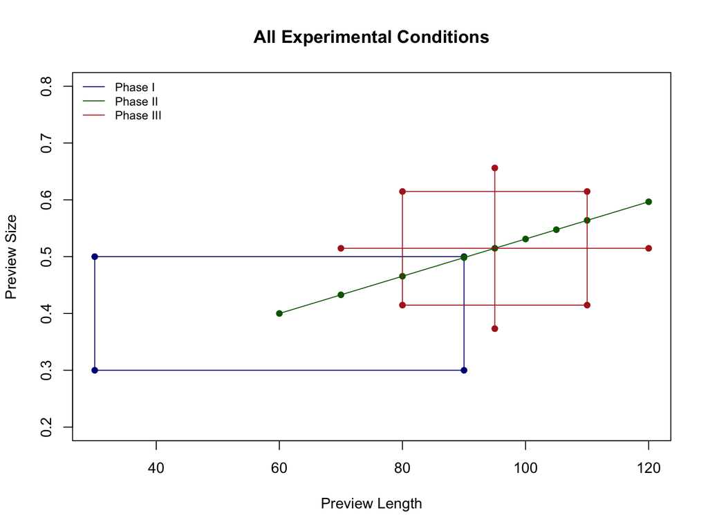

```r
## Phase I
ph1.cond <- data.frame(Prev.Length = c(30,90,30,90),
                  Prev.Size = c(0.3, 0.3, 0.5, 0.5))
plot(x = ph1.cond$Prev.Length, y = ph1.cond$Prev.Size, pch = 16, col = "navyblue", ylim = c(0.2, 0.8), xlim = c(30, 120), xlab = "Preview Length", ylab = "Preview Size", main = "All Experimental Conditions")
segments(x0 = 30, y0 = 0.3, x1 = 90, y1 = 0.3, col = "navyblue")
segments(x0 = 30, y0 = 0.5, x1 = 90, y1 = 0.5, col = "navyblue")
segments(x0 = 30, y0 = 0.3, x1 = 30, y1 = 0.5, col = "navyblue")
segments(x0 = 90, y0 = 0.3, x1 = 90, y1 = 0.5, col = "navyblue")

## Phase II
ph2.cond <- data.frame(Prev.Length = c(60,70,80,90,95,100,105,110,120),
                  Prev.Size = c(0.4000000, 0.4327683, 0.4655365, 0.4983048, 0.5146889, 0.5310731, 0.5474572, 0.5638413, 0.5966096))
points(x = ph2.cond$Prev.Length, y = ph2.cond$Prev.Size, pch = 16, col = "darkgreen")
lines(x = ph2.cond$Prev.Length, y = ph2.cond$Prev.Size, col = "darkgreen")

## Phase III
ph3.cond <- data.frame(Prev.Length = c(80,110,80,110,70,120,95,95),
                  Prev.Size = c(0.4146889,0.4146889,0.6146889,0.6146889,0.5146889,0.5146889,0.3732675,0.6561103))
points(x = ph3.cond$Prev.Length, y = ph3.cond$Prev.Size, pch = 16, col = "firebrick")
segments(x0 = 80, y0 = 0.4146889, x1 = 110, y1 = 0.4146889, col = "firebrick")
segments(x0 = 80, y0 = 0.6146889, x1 = 110, y1 = 0.6146889, col = "firebrick")
segments(x0 = 80, y0 = 0.4146889, x1 = 80, y1 = 0.6146889, col = "firebrick")
segments(x0 = 110, y0 = 0.4146889, x1 = 110, y1 = 0.6146889, col = "firebrick")
segments(x0 = 95, y0 = 0.3732675, x1 = 95, y1 = 0.6561103, col = "firebrick")
segments(x0 = 70, y0 = 0.5146889, x1 = 120, y1 = 0.5146889, col = "firebrick")

legend("topleft", legend = c("Phase I", "Phase II", "Phase III"),
       col = c("navyblue", "darkgreen", "firebrick"), lty = 1, cex = 0.8, bty = "n")
```